# Technology Transfer under the Asymmetric Information

30 4 2018

## Technology transfer under asymmetric information

workingDirectory <- getwd()

grid.arrange(img1, img2, ncol = 2)

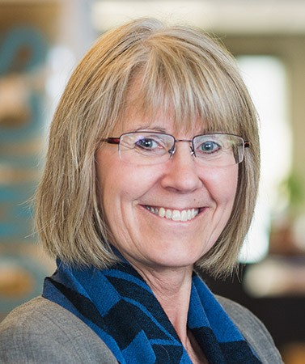

Nancy T. Gallini

## Brian D. Wright

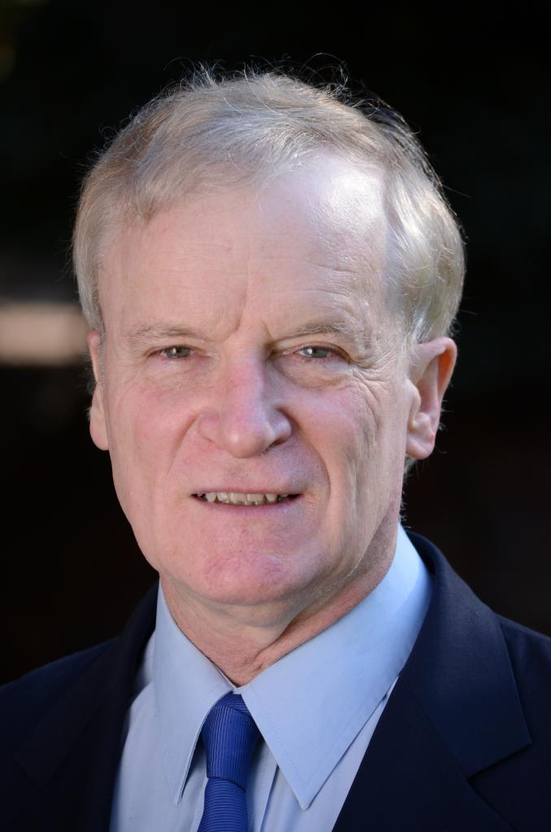

Brian D. Wright

## Structure

What is the *research question*?  
How does the question fall into the field?  
What can we gain?  
What is the *contribution*?  
What is the *methodological approach*?

## Introduction

**What explains the the form of the contract for newly patented innovations?**

1. Asymmetric information about the value of the innovation
2. The problem of imitation by a licensee

## Research question

**Principle-agent problem:** How do you design a licensing contract that maximizes profit if both parties may be opportunistic?

## Contribution

**Bhattacharya and Ritter** (1983): **pre**innovation to potential financiers of an R&D projects

**Gallini and Wrights** (1990): **post**innovation signalling to potential purchasers of the rights to the innovation

## The problem of innovation transfer

- Feasible contracts \((n, F, P(x))\)
- The potential to imitate
  - type A (low-cost)
  - type B (high-cost)
- The nature of information asymmetries and the game

## Contractual design under asymmetric information

Separating equilibrium contract for a licensor with a type A innovation.

Total payments to the type A licensor specified in the contract must satisfy:

- Rationality \(F \leq V_A{(s)} - P(x_A{(s)})\)
- No imitation \(V_A(s) - P(x_A(s)) \leq W_A(s) - I\)
- Separation \(n[F + P(x_B(s))] \leq \pi_B\)

## Exclusive contracts

A per-unit royalty reduces output below the monopoly level, which prevents full monopoly profits from being realized.

## Exclusive contracts for nondrastic innovations

A linear exclusive contract with a constant royalty does **not** distort output for "run-of-the-mill" (nondrastic) innovations when the **pre**innovation price is competitive.

## Nonexclusive contracts for product or drastic innovations

With competing licensees, the per-unit royalty reduces output to the monopoly level by raising each firm's marginal cost.

When **imitation costs** are **large** enough that an output royalty will not induce firms to invent around the technology, **contracts with a simple constant royalty *can* extract all the rents**.

\(I \ge W_A(s_n^*) - (\pi_A/n - Rx_A(s_n^*)) \equiv z(s_n^*)\)

A constant per-unit royalty raises marginal costs and results in too little output under an exclusive license, but reduces output to the monopoly level in a market with multiple Cournot licensees.

## The separating equilibrium contracts

Separating equilibrium contract may have a simple linear payment scheme.

## Separating equilibrium contracts for a technology

## Conclusions

*Innovations with relatively low values (type B):* - can be fully exploited with an exclusive contract and a fixed fee

## Critique

- The paper was published 28 years ago.
- No continious types, only A and B
- Many assumptions are too strong, e.g. risk-neutrality.
- What would have happened if they were not risk-neutral.
- Loss of generality
- Is there a pooling equilibrium
- "…behave like Cournot firms". Why not like Stackelberg or Bertrand firms?